# Chapter 2: regression and model validation

*Goal of this project is to practice regression and model validation with R on a dataset which is saved in the directory IODS-project under the name “learning2014”. The dataset is obtained from the first part of the RStudio Exercise 2, with the code available at [my Github repository](https://github.com/scarabel/IODS-project/blob/master/data/create_learning2014.R).*

What I learnt:

- to produce summaries and graphical representations of the data
- to fit a linear regression model to the data
- to validate the model with graphical tools

## The database

I first load the dataset from the folder IODS-project and save it with name “students2014”.

```r
setwd("~/GitHub/IODS-project")
options(max.print=2000)
students2014 <- read.csv("learning2014")
```

The structure of the database can be explored with the instruction `str`:

```r
str(students2014)
```

```
## 'data.frame':    166 obs. of  8 variables:
##  $ X       : int  1 2 3 4 5 6 7 8 9 10 ...
##  $ gender  : Factor w/ 2 levels "F","M": 1 2 1 2 2 1 2 1 2 1 ...
##  $ age     : int  53 55 49 53 49 38 50 37 37 42 ...
##  $ attitude: int  37 31 25 35 37 38 35 29 38 21 ...
##  $ deep    : num  3.58 2.92 3.5 3.5 3.67 ...
##  $ stra    : num  3.38 2.75 3.62 3.12 3.62 ...
##  $ surf    : num  2.58 3.17 2.25 2.25 2.83 ...
##  $ points  : int  25 12 24 10 22 21 21 31 24 26 ...
```

The database contains a summary of the information about statistical learning collected by Kimmo Venhalahti during the period 3.12.2014 - 10.1.2015, from the students attnding the course *Johdatus yhteiskuntatilastotieteeseen*. The full information was collected and summarised in the following fields:

- age = age in years;
- gender = gender of the students (M or F);
- attitude = attitude towards statistics;
- deep = summary of the variables characterising deep learning;
- stra = summary of the variables characterising strategic learning;
- surf = summary of the variables characterising surface learining;
- points = exam grade.

The database has 166 entries containing the data for every students who got a positive final grade.

## Graphical overview and summary of the data

I first give an overview of the age and gender of the interviewed students.

```r
summary(students2014$age)
```

```
##    Min. 1st Qu.  Median    Mean 3rd Qu.    Max.
##   17.00   21.00   22.00   25.51   27.00   55.00
```

```r
summary(students2014$gender)
```

```
##   F   M
## 110  56
```

To explore the relations between the variables, I create a scattered plot of the different variables, keeping track of the gender. To plot the results, I first load the library `ggplot2` and `GGally`

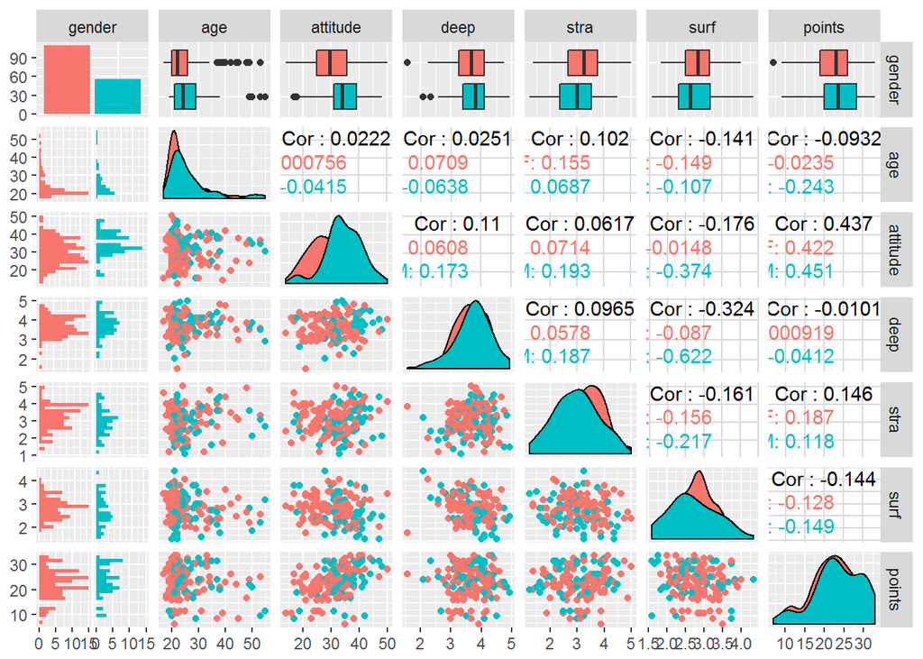

Some remarks about the results

I will explore graphically specifically the correlation between points and attitude, strategic learning and surface learning. In particular, below I repeat the graphic relation between the variables, including their linear regression line fitted to the data.

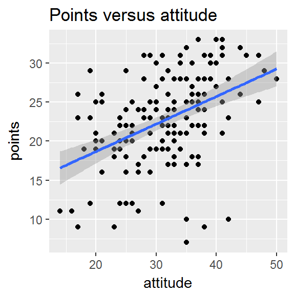

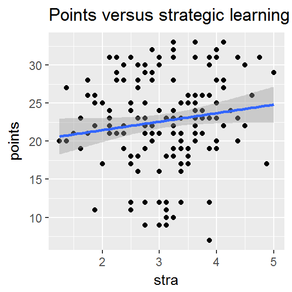

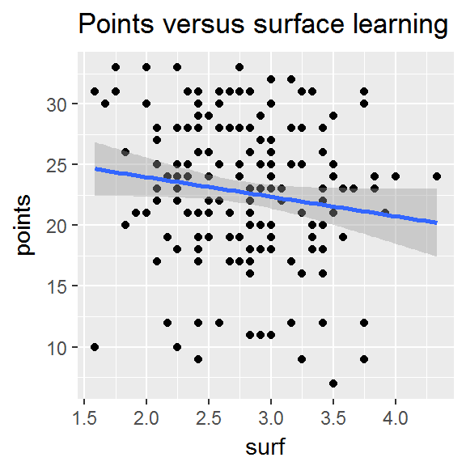

## Fitting a statistical linear regression model

I now fit a regression model for the target variable *point*, with explanatory variables $x_1=$ *attitude*, $x_2=$ *strategic learning* and $x_3=$ *surface learning*.

```r
my_model <- lm(points ~ attitude + stra + surf, data = students2014)
summary(my_model)
```

```
##
## Call:
## lm(formula = points ~ attitude + stra + surf, data = students2014)
##
## Residuals:
##      Min       1Q   Median       3Q      Max
## -17.1550  -3.4346   0.5156   3.6401  10.8952
##
## Coefficients:
##             Estimate Std. Error t value Pr(>|t|)
## (Intercept) 11.01711    3.68375   2.991  0.00322 **
## attitude     0.33952    0.05741   5.913 1.93e-08 ***
## stra         0.85313    0.54159   1.575  0.11716
## surf        -0.58607    0.80138  -0.731  0.46563
## ---
## Signif. codes:  0 '***' 0.001 '**' 0.01 '*' 0.05 '.' 0.1 ' ' 1
##
## Residual standard error: 5.296 on 162 degrees of freedom
## Multiple R-squared:  0.2074, Adjusted R-squared:  0.1927
## F-statistic: 14.13 on 3 and 162 DF,  p-value: 3.156e-08
```

The summary of the statistical model provides the coefficients of the multiple linear regression model for the explanatory variables $x_1,x_2,x_3$. The coefficients are $\beta_1 \approx 0.33, \beta_2 \approx 0.85, \beta_3 \approx -0.58$.

To understand the significance of the model, we look at the p-value, `Pr(>|t|)`. We observe that the p-value corresponding to the surface learning is very high, so this variable is probably not relevant in explaining the exam points.

We therefore take it out the model and consider only the first two explanatory variables.

```r
my_model2 <- lm(points ~ attitude + stra, data = students2014)
summary(my_model2)
```

```
##
## Call:
## lm(formula = points ~ attitude + stra, data = students2014)
##
## Residuals:
##      Min       1Q   Median       3Q      Max
## -17.6436  -3.3113   0.5575   3.7928  10.9295
##
## Coefficients:
##             Estimate Std. Error t value Pr(>|t|)
## (Intercept)  8.97290    2.39591   3.745  0.00025 ***
## attitude     0.34658    0.05652   6.132 6.31e-09 ***
## stra         0.91365    0.53447   1.709  0.08927 .
## ---
## Signif. codes:  0 '***' 0.001 '**' 0.01 '*' 0.05 '.' 0.1 ' ' 1
##
## Residual standard error: 5.289 on 163 degrees of freedom
## Multiple R-squared:  0.2048, Adjusted R-squared:  0.1951
## F-statistic: 20.99 on 2 and 163 DF,  p-value: 7.734e-09
```

## Interpretation of the regression coefficients

In this new model, the coefficients of the explanatory variables are $\beta_1\approx 0.34$ and $\beta_2\approx 0.91$. This means that for any unitary increase of attitude or strategic learning, the points are expected to increase of 0.34 or 0.91, respectively. Hence, the strategic learning seems to have a higher effect on the exam points.

The value of $R^2$ indicates how well the data are explained by the linear regression model. A value of 0.2 indicates that the data are quite scattered away from the regression line (i.e., the dispersion of the data is quite high). Compare also the previous plots of points vs attitude and points vs strategic learning.

## Graphical model validation

To understand how reasonable is the assumption $\epsilon \sim N(0,\sigma^2)$, I plot the diagnostic plots: Residuals vs Fitted values, Normal QQ-plot and Residuals vs Leverage.

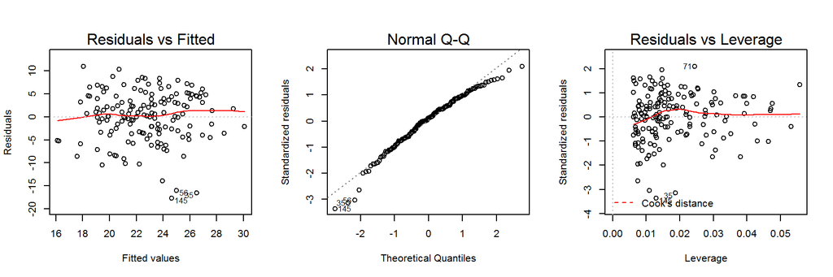

- From the first plot, there seems to be no pattern between data and residuals. Hence it is reasonable to assume that the noise $\epsilon$ is independent of the data (i.e., the variance $\sigma^2$ is constant).
- The second plot shows that the stardardised residuals fit well with the straight line: the normality assumption is reasonable.
- The third plot shows that there are no important outliers in the data that have high impact in the fitting of the model. Notice the small values of the leverage in the $x$-axis.